# Lecture 5: Bootstrap Confidence Intervals and Hypothesis Testing

Se Yoon Lee

2026-06-27

## 1 Today’s Question

In Lectures 2, 3, and 4, we estimated the adjusted difference in CVD risk between smokers and non-smokers.

Those lectures gave us **point estimates**:

> one best guess from one dataset.

Lecture 5 asks a new question:

> How uncertain are those estimates?

We will use the **bootstrap** to build 95% confidence intervals and do hypothesis testing for:

1. IPW
2. Outcome regression
3. Doubly robust estimation

Our teaching analysis still uses the same variables and does **not use survey weights**.

| Symbol | Meaning in this lecture |
| --- | --- |
| `T` | Smoking status: 1 = smoker, 0 = non-smoker |
| `Y` | CVD status: 1 = had CVD, 0 = did not have CVD |
| `X` | Age, gender, race, education, income-to-poverty ratio, and BMI |

## 2 Why Bootstrap?

A point estimate is like taking one photo.

A confidence interval asks:

> If we could repeat the study many times, how much might the estimate move around?

But we usually have only one dataset. The bootstrap uses that one dataset to create many “pretend new datasets.”

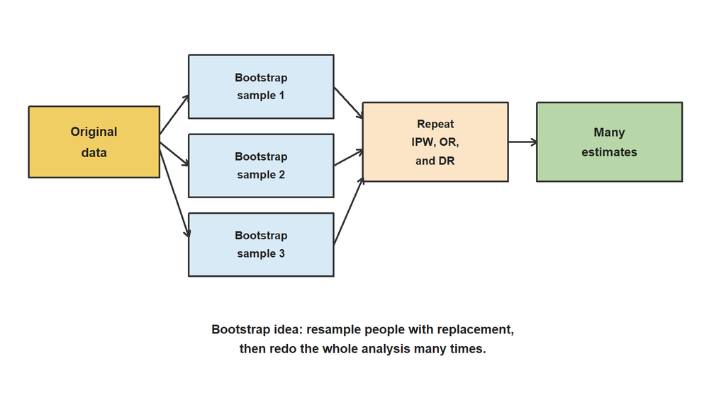

## 3 Bootstrap Sampling

In one bootstrap sample:

1. We randomly draw the same number of people as the original dataset.
2. We draw **with replacement**, so one person can appear more than once.
3. Some people from the original dataset may not appear in that bootstrap sample.
4. We refit the models and recalculate the adjusted risk difference.

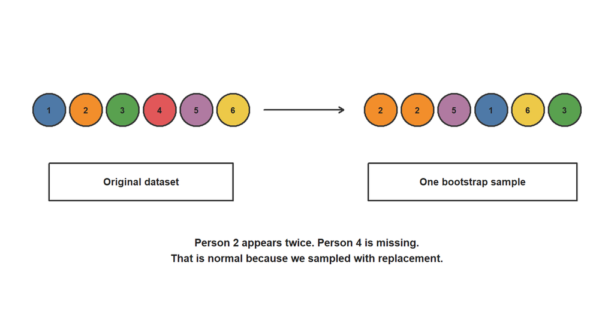

## 4 Load and Prepare the Data

```r
data_path <- file.path("..", "Data", "NHANES_data.csv")

if (!file.exists(data_path)) {
  data_path <- file.path("Data", "NHANES_data.csv")
}

nhanes <- read.csv(data_path, stringsAsFactors = FALSE)

baseline_vars <- c(
  "age_yr",
  "gender",
  "race",
  "educ_lvl",
  "inc_to_pov_ratio",
  "bmi"
)

analysis_vars <- c("smoker_indicator", "cvd_indicator", baseline_vars)

analysis_data <- nhanes[complete.cases(nhanes[, analysis_vars]), analysis_vars]

analysis_data$smoker_indicator <- as.integer(analysis_data$smoker_indicator)
analysis_data$cvd_indicator <- as.integer(analysis_data$cvd_indicator)

analysis_data$smoking_group <- ifelse(
  analysis_data$smoker_indicator == 1,
  "Smoker",
  "Non-smoker"
)

analysis_data$smoking_group <- factor(
  analysis_data$smoking_group,
  levels = c("Non-smoker", "Smoker")
)

analysis_data$gender_label <- factor(
  analysis_data$gender,
  levels = c("F", "M"),
  labels = c("Female", "Male")
)

analysis_data$race_label <- factor(
  analysis_data$race,
  levels = c(
    "mex_american",
    "other_hispanic",
    "nh_white",
    "nh_black",
    "nh_asian"
  ),
  labels = c(
    "Mexican American",
    "Other Hispanic",
    "Non-Hispanic White",
    "Non-Hispanic Black",
    "Non-Hispanic Asian"
  )
)

analysis_data$educ_label <- factor(
  analysis_data$educ_lvl,
  levels = c(
    "lt_9th_grade",
    "9_to_12th_grade_no_diploma",
    "hs_grad_or_ged",
    "start_college_to_aa",
    "college_grad_or_above"
  ),
  labels = c(
    "Less than 9th grade",
    "9th-12th, no diploma",
    "High school or GED",
    "Some college or AA",
    "College graduate or above"
  )
)

nrow(analysis_data)
```

```
## [1] 6299
```

```r
sample_summary <- data.frame(
  Quantity = c(
    "Number of people",
    "Number of smokers",
    "Number of non-smokers",
    "Number with CVD"
  ),
  Value = c(
    nrow(analysis_data),
    sum(analysis_data$smoker_indicator == 1),
    sum(analysis_data$smoker_indicator == 0),
    sum(analysis_data$cvd_indicator == 1)
  )
)

knitr::kable(sample_summary)
```

| Quantity | Value |
| --- | --- |
| Number of people | 6299 |
| Number of smokers | 2559 |
| Number of non-smokers | 3740 |
| Number with CVD | 646 |

## 5 The Estimators We Will Bootstrap

Each bootstrap sample repeats the same three adjusted analyses.

```r
weighted_mean <- function(outcome, weights) {
  sum(weights * outcome) / sum(weights)
}

fit_three_methods <- function(input_data) {
  treatment_model <- glm(
    smoker_indicator ~ age_yr + gender_label + race_label +
      educ_label + inc_to_pov_ratio + bmi,
    data = input_data,
    family = binomial()
  )

  e_hat <- predict(treatment_model, type = "response")

  outcome_model <- glm(
    cvd_indicator ~ smoker_indicator + age_yr + gender_label +
      race_label + educ_label + inc_to_pov_ratio + bmi,
    data = input_data,
    family = binomial()
  )

  data_if_non_smoker <- input_data
  data_if_smoker <- input_data

  data_if_non_smoker$smoker_indicator <- 0
  data_if_smoker$smoker_indicator <- 1

  m0_hat <- predict(
    outcome_model,
    newdata = data_if_non_smoker,
    type = "response"
  )

  m1_hat <- predict(
    outcome_model,
    newdata = data_if_smoker,
    type = "response"
  )

  smoker_rows <- input_data$smoker_indicator == 1
  non_smoker_rows <- input_data$smoker_indicator == 0

  ipw_risk_smoker <- weighted_mean(
    input_data$cvd_indicator[smoker_rows],
    1 / e_hat[smoker_rows]
  )

  ipw_risk_non_smoker <- weighted_mean(
    input_data$cvd_indicator[non_smoker_rows],
    1 / (1 - e_hat[non_smoker_rows])
  )

  ipw_difference <- ipw_risk_smoker - ipw_risk_non_smoker

  or_risk_smoker <- mean(m1_hat)
  or_risk_non_smoker <- mean(m0_hat)
  or_difference <- or_risk_smoker - or_risk_non_smoker

  T_obs <- input_data$smoker_indicator
  Y_obs <- input_data$cvd_indicator

  dr_risk_smoker <- mean(m1_hat + T_obs / e_hat * (Y_obs - m1_hat))
  dr_risk_non_smoker <- mean(
    m0_hat + (1 - T_obs) / (1 - e_hat) * (Y_obs - m0_hat)
  )

  dr_difference <- dr_risk_smoker - dr_risk_non_smoker

  c(
    IPW = ipw_difference,
    Outcome_regression = or_difference,
    Doubly_robust = dr_difference
  )
}

safe_fit_three_methods <- function(input_data) {
  tryCatch(
    fit_three_methods(input_data),
    error = function(e) {
      c(IPW = NA_real_,
        Outcome_regression = NA_real_,
        Doubly_robust = NA_real_)
    }
  )
}
```

## 6 Point Estimates From the Original Dataset

```r
original_estimates <- fit_three_methods(analysis_data)

original_table <- data.frame(
  Method = c("IPW", "Outcome regression", "Doubly robust"),
  Risk_difference_percentage_points = round(100 * original_estimates, 2)
)

knitr::kable(
  original_table,
  col.names = c("Method", "Risk difference: smoker minus non-smoker")
)
```

|  | Method | Risk difference: smoker minus non-smoker |
| --- | --- | --- |
| IPW | IPW | 2.99 |
| Outcome_regression | Outcome regression | 3.45 |
| Doubly_robust | Doubly robust | 3.25 |

These are the point estimates. Now we will use bootstrapping to estimate their uncertainty.

## 7 Run the Bootstrap

For this lecture note, we use `B = 300` bootstrap samples so the file can knit quickly. In a research project, it is common to use more, such as 1000 or 2000.

```r
set.seed(20260627)

B <- 300
n <- nrow(analysis_data)

bootstrap_estimates <- matrix(
  NA_real_,
  nrow = B,
  ncol = length(original_estimates)
)

colnames(bootstrap_estimates) <- names(original_estimates)

for (b in seq_len(B)) {
  bootstrap_rows <- sample.int(n, size = n, replace = TRUE)
  bootstrap_data <- analysis_data[bootstrap_rows, ]
  bootstrap_estimates[b, ] <- safe_fit_three_methods(bootstrap_data)
}

bootstrap_estimates <- bootstrap_estimates[complete.cases(bootstrap_estimates), ]

number_of_successful_bootstraps <- nrow(bootstrap_estimates)
number_of_successful_bootstraps
```

```
## [1] 300
```

## 8 Build 95% Confidence Intervals

We use a simple **percentile bootstrap interval**.

For each method:

1. Sort the bootstrap estimates.
2. Take the 2.5th percentile.
3. Take the 97.5th percentile.
4. The middle 95% is the confidence interval.

```r
bootstrap_se <- apply(bootstrap_estimates, 2, sd)

bootstrap_ci <- t(apply(
  bootstrap_estimates,
  2,
  quantile,
  probs = c(0.025, 0.975),
  na.rm = TRUE
))

colnames(bootstrap_ci) <- c("Lower", "Upper")

inference_table <- data.frame(
  Method = c("IPW", "Outcome regression", "Doubly robust"),
  Estimate_pp = round(100 * original_estimates, 2),
  Bootstrap_SE_pp = round(100 * bootstrap_se, 2),
  CI_lower_pp = round(100 * bootstrap_ci[, "Lower"], 2),
  CI_upper_pp = round(100 * bootstrap_ci[, "Upper"], 2)
)

knitr::kable(
  inference_table,
  col.names = c(
    "Method",
    "Estimate (pp)",
    "Bootstrap SE (pp)",
    "95% CI lower (pp)",
    "95% CI upper (pp)"
  )
)
```

|  | Method | Estimate (pp) | Bootstrap SE (pp) | 95% CI lower (pp) | 95% CI upper (pp) |
| --- | --- | --- | --- | --- | --- |
| IPW | IPW | 2.99 | 0.79 | 1.62 | 4.56 |
| Outcome_regression | Outcome regression | 3.45 | 0.79 | 2.11 | 5.02 |
| Doubly_robust | Doubly robust | 3.25 | 0.80 | 1.94 | 4.92 |

Here, `pp` means **percentage points**.

For example, a risk difference of 3.0 percentage points means:

> CVD risk is estimated to be 3.0 percentage points higher under smoking than under non-smoking.

## 9 Picture of the Bootstrap Distributions

Each histogram shows the bootstrap estimates from many pretend datasets.

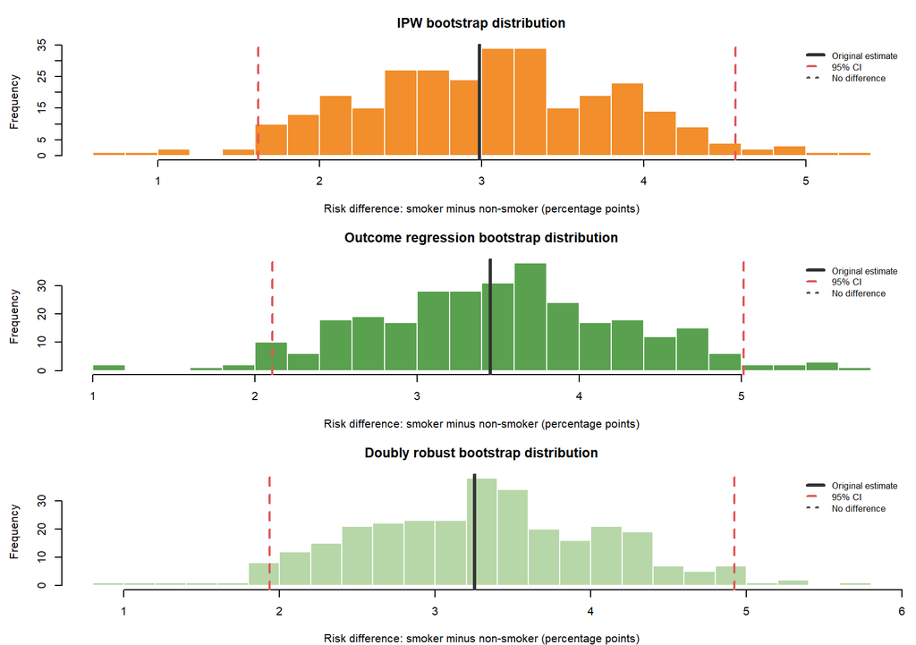

If the bootstrap estimates are tightly packed, the method has a smaller standard error. If they are more spread out, the estimate is more uncertain.

## 10 Picture of the 95% Confidence Intervals

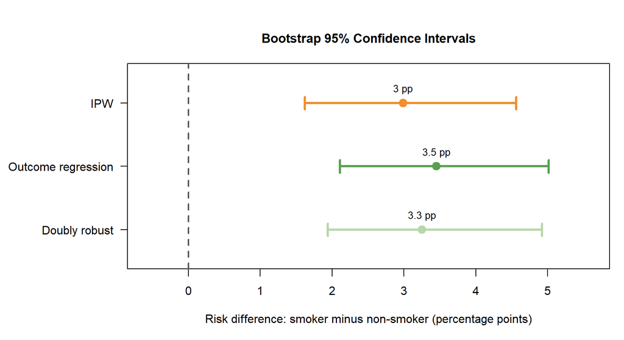

The dashed vertical line means **zero difference**.

If a confidence interval does not cross zero, that suggests the adjusted difference is unlikely to be exactly zero.

## 11 Hypothesis Testing

Now we formally ask:

> Is there evidence that the adjusted CVD risk is different for smokers and non-smokers?

For each method, our hypotheses are:

H0: adjusted risk difference = 0

H1: adjusted risk difference is not 0

The null hypothesis `H0` means:

> After adjustment, smoking and non-smoking have the same CVD risk.

The alternative hypothesis `H1` means:

> After adjustment, smoking and non-smoking have different CVD risk.

## 12 Bootstrap Standard Error Test

We estimate the standard error using the bootstrap:

```r
z_statistic <- original_estimates / bootstrap_se
p_value <- 2 * (1 - pnorm(abs(z_statistic)))

hypothesis_table <- data.frame(
  Method = c("IPW", "Outcome regression", "Doubly robust"),
  Estimate_pp = round(100 * original_estimates, 2),
  Bootstrap_SE_pp = round(100 * bootstrap_se, 2),
  Z_statistic = round(z_statistic, 2),
  P_value = signif(p_value, 3),
  Conclusion_at_0_05 = ifelse(
    p_value < 0.05,
    "Reject H0",
    "Do not reject H0"
  )
)

knitr::kable(
  hypothesis_table,
  col.names = c(
    "Method",
    "Estimate (pp)",
    "Bootstrap SE (pp)",
    "z",
    "p-value",
    "Conclusion at 0.05"
  )
)
```

|  | Method | Estimate (pp) | Bootstrap SE (pp) | z | p-value | Conclusion at 0.05 |
| --- | --- | --- | --- | --- | --- | --- |
| IPW | IPW | 2.99 | 0.79 | 3.76 | 1.71e-04 | Reject H0 |
| Outcome_regression | Outcome regression | 3.45 | 0.79 | 4.37 | 1.22e-05 | Reject H0 |
| Doubly_robust | Doubly robust | 3.25 | 0.80 | 4.08 | 4.57e-05 | Reject H0 |

The p-value is a way to measure how surprising our estimate would be if the true adjusted risk difference were really zero.

Small p-values give evidence against `H0`.

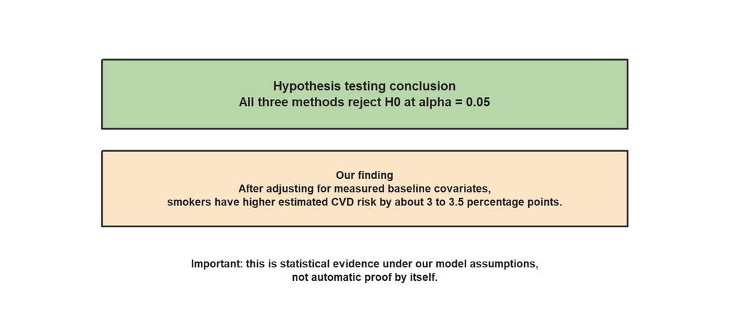

## 13 Hypothesis Test Picture

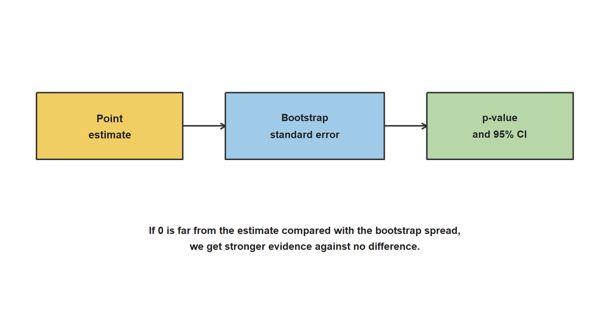

## 14 Interpretation

For this complete-case classroom sample:

```r
interpretation_table <- data.frame(
  Method = c("IPW", "Outcome regression", "Doubly robust"),
  Estimate = paste0(round(100 * original_estimates, 1), " pp"),
  CI_95 = paste0(
    "(",
    round(100 * bootstrap_ci[, "Lower"], 1),
    ", ",
    round(100 * bootstrap_ci[, "Upper"], 1),
    ") pp"
  ),
  P_value = signif(p_value, 3)
)

knitr::kable(
  interpretation_table,
  col.names = c("Method", "Estimate", "95% CI", "p-value")
)
```

|  | Method | Estimate | 95% CI | p-value |
| --- | --- | --- | --- | --- |
| IPW | IPW | 3 pp | (1.6, 4.6) pp | 1.71e-04 |
| Outcome_regression | Outcome regression | 3.5 pp | (2.1, 5) pp | 1.22e-05 |
| Doubly_robust | Doubly robust | 3.3 pp | (1.9, 4.9) pp | 4.57e-05 |

The IPW, outcome-regression, and doubly robust estimates all compare the predicted CVD risk if everyone were a smoker with the predicted CVD risk if everyone were a non-smoker, after adjusting for measured baseline covariates.

If a method’s 95% confidence interval is entirely above zero, the bootstrap analysis suggests evidence that the adjusted smoker risk is higher than the adjusted non-smoker risk.

But this still depends on causal assumptions:

1. We adjusted for the important confounders.
2. Smokers and non-smokers have enough overlap in covariates.
3. The models used by each method are reasonable enough.
4. The data were measured well enough for this teaching question.

## 15 What the Bootstrap Does Not Fix

Bootstrap helps with **random sampling uncertainty**.

It does not automatically fix:

1. Unmeasured confounding
2. Bad measurement
3. Poor model choices
4. Lack of overlap
5. Survey-design issues that we intentionally skipped for this high-school-level lesson

So the bootstrap tells us:

> How much our estimate moves around because the sample could have been different.

It does not prove:

> Smoking caused the exact difference we estimated.

## 16 Key Takeaways

1. A point estimate gives one best guess.
2. A bootstrap confidence interval shows uncertainty around that guess.
3. Bootstrapping repeats the whole analysis on many resampled datasets.
4. We used bootstrapping for IPW, outcome regression, and doubly robust estimation.
5. Hypothesis testing asks whether zero difference is plausible.
6. Statistical evidence is not the same as causal proof; causal assumptions still matter.